# Milk

## Ostateczne wykresy

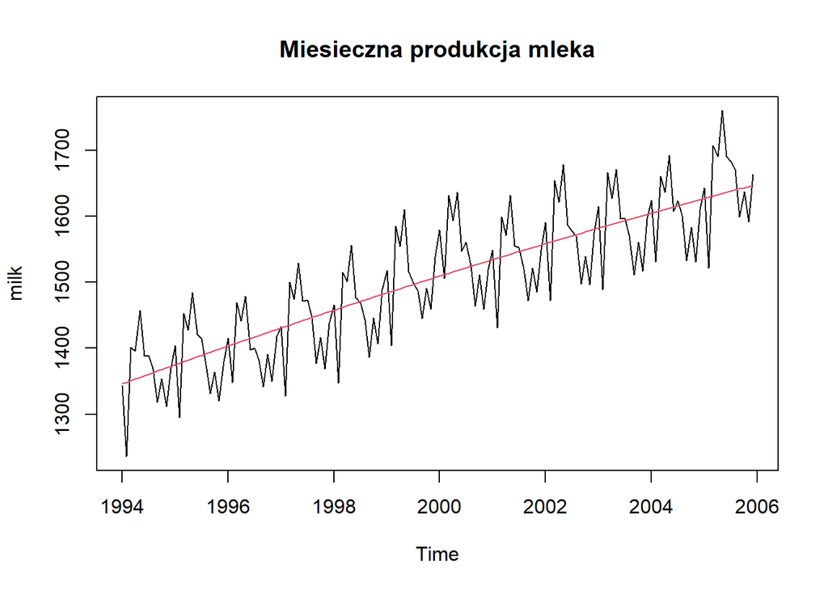

```r
plot(milk, main= "Miesieczna produkcja mleka")
lines(yr2, col= 2)
```

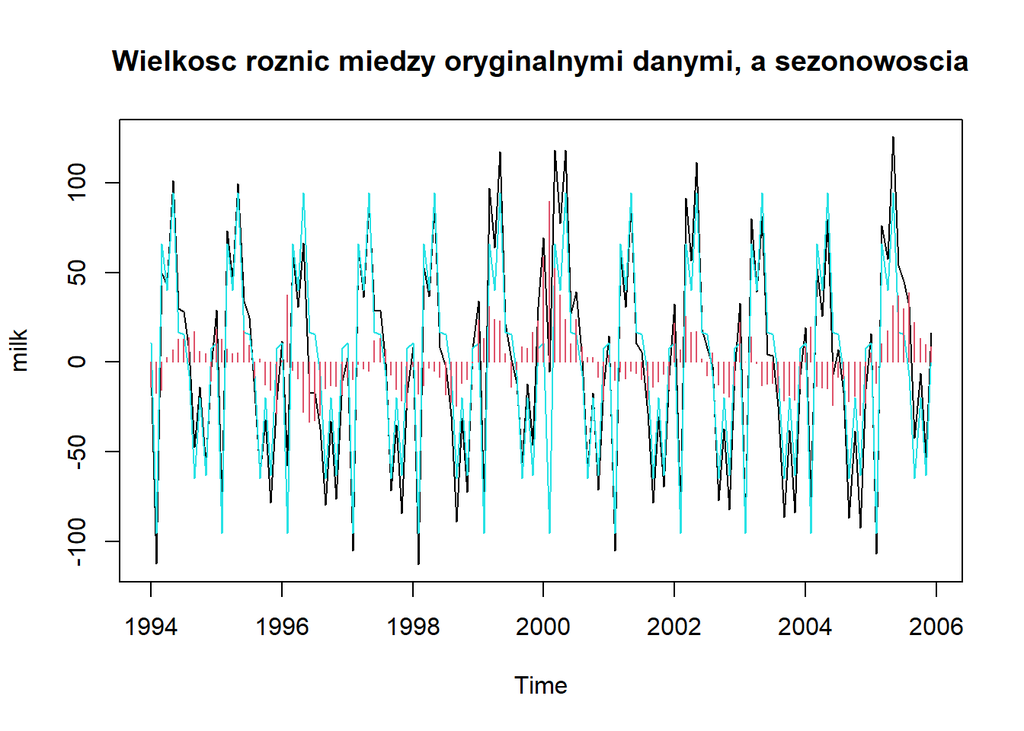

```r
plot(milk- yr2, main= "Wielkosc roznic miedzy oryginalnymi danymi, a sezonowoscia") # Dane bez trendu
lines(sez, col= 5) # Sezon
lines(milk- yr2- sez, col= 2, type= "h")
```

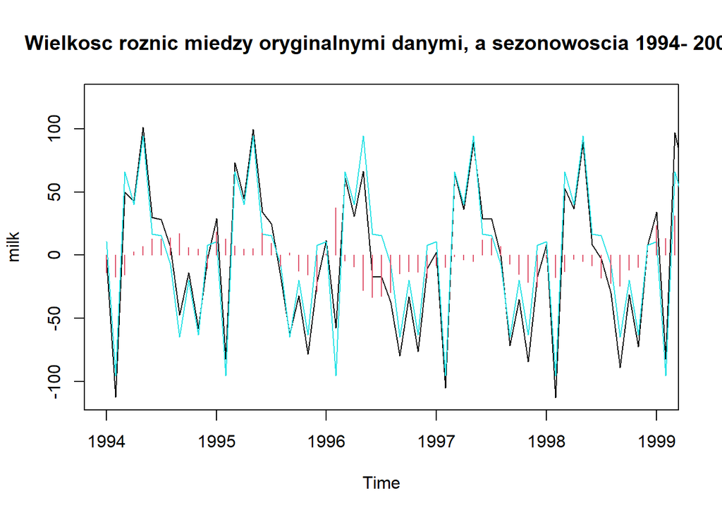

```r
# Mozemy dostrzec pewna anomalie (najwiekszy odchyl sezonu od oryginalnych danych) w latach 1999-2001
# Podzielmy wykres na 3 czesci

sr <- mean(time(milk))
plot(milk- yr2, main= "Wielkosc roznic miedzy oryginalnymi danymi, a sezonowoscia 1994- 2001", xlim= c(1994,1999)) # Dane bez trendu
lines(sez, col= 5) # Sezon
lines(milk- yr2- sez, col= 2, type= "h")
```

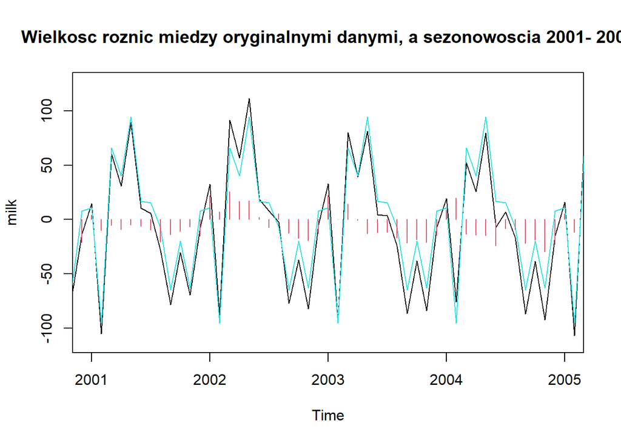

```r
plot(milk- yr2, main= "Wielkosc roznic miedzy oryginalnymi danymi, a sezonowoscia 2001- 2006", xlim= c(2001,2005)) # Dane bez trendu
lines(sez, col= 5) # Sezon
lines(milk- yr2- sez, col= 2, type= "h")
```

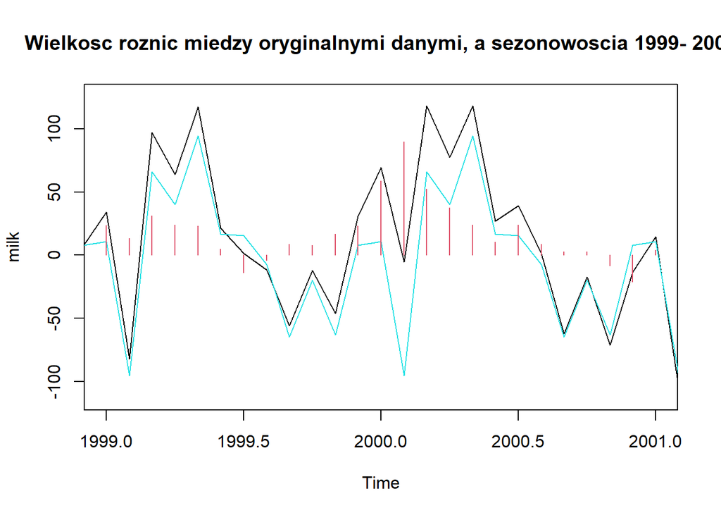

```r
plot(milk- yr2, main= "Wielkosc roznic miedzy oryginalnymi danymi, a sezonowoscia 1999- 2001", xlim= c(1999,2001)) # Dane bez trendu
lines(sez, col= 5) # Sezon
lines(milk- yr2- sez, col= 2, type= "h")
```

```r
# Teraz rowniez latwiej zauwazyc, ze na przelomie roku 2000-go, (chwilowo) znacznie wzrosla produkcja mleka
```

## Siła trendu i sezonowości - ciekawostka

https://otexts.com/fpp3/stlfeatures.html

```r
res <- milk- yr2- sez
Rt <- var(res)
Tt <- var(yr2)
St <- var(sez)
# Sila trendu
cat("Sila trendu z przedzialu [0,1]:      ",max(0,1-Rt/(var(yr2+res))),"\n")
```

```
## Sila trendu z przedzialu [0,1]:       0.9549195
```

```r
# Sila sezonowosci
cat("Sila sezonowosci z przedzialu [0,1]: ",max(0,1-Rt/(var(sez-res))),"\n")
```

```
## Sila sezonowosci z przedzialu [0,1]:  0.8734662
```

Powyższe traktuję jako pewne uświadomomienie na temat siły trendu i sezonowości dla zbioru milk. Jak widać, te siły są bardzo duże. Ta metoda bywa stosowana do wizualizacji sił trendu i sezonowości w przypadku danych z wieloma zmiennymi/kolumnami.

## Część II - walidacja modeli wraz z predykcjami

**Kliknij, aby rozwinąć**

### Wykorzystanie pakietu “itsmr”

Po ręcznej dekompozycji szeregu czasowego, przejdziemy do wykorzsytania bilbioteki “itsmr” do zbudowania modelu oraz wykonania predykcji.

#### Utworzenie modelu ARMA() z biblioteką “itsmr”

Wykorzystując funkcję acf() oraz pacf() zbadajmy resztki ze zbioru “milk”. Pozwoli nam to okreslić dobranie p,q do modelu ARMA(p,q).

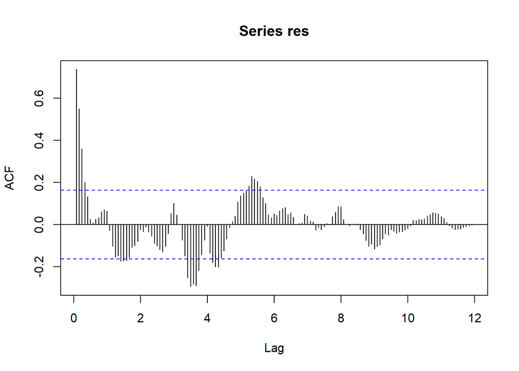

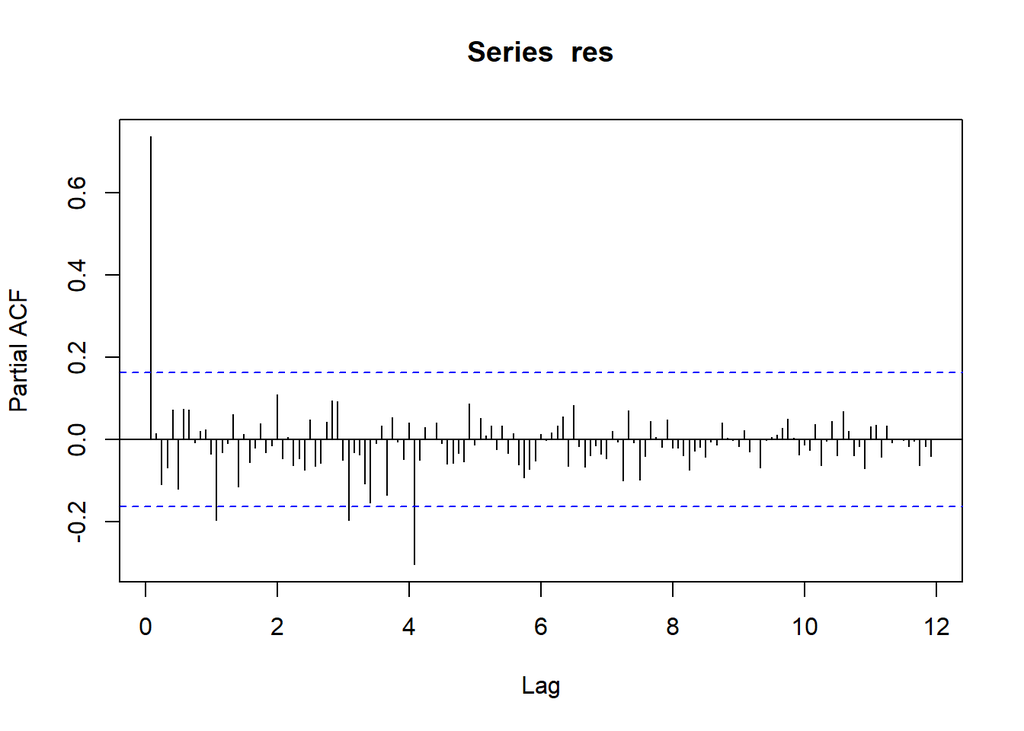

```
## [1]  0.73703561  0.01421027 -0.10887834 -0.06820482  0.07203370
```

W przypadku autokorelacji, nie ma wyróżniającego się kandydata (Lag-u) dla modelu $MA(q)$. Natomiast w przypadku częściowej autokrelacji (korelogramu) widzimy, że na pierwszej pozycji występuje znaczna istotność ($0.73703561$). Oznacza to, że kandydatami na wartości w modelu $ARMA(p,q)$ będą $p=1, \;q=0\iff ARMA(1,0) \iff AR(1)$. Istotnie, porównajmy zaproponowany model z wynikiem wbudowanej funkcji autofit() z pakietu “itsmr”, która sprawdza zadane parametry modelu tak, aby zminimalizować błąd AICc.

```
## ARMA(1,0)
```

```
## $phi
## [1] 0.7355615
##
## $theta
## [1] 0
##
## $sigma2
## [1] 168.5047
##
## $aicc
## [1] 1151.801
##
## $se.phi
## [1] 0.05561624
##
## $se.theta
## [1] 0
```

```
## autofit(res)
```

```
## $phi
## [1] 0.7355615
##
## $theta
## [1] 0
##
## $sigma2
## [1] 168.5047
##
## $aicc
## [1] 1151.801
##
## $se.phi
## [1] 0.05561624
##
## $se.theta
## [1] 0
```

Jak widzimy, w podanym zakresie parametrów model $ARMA(1,0)$ został wybrany jako optymalny. Dodatkowo, wyróżnijmy błąd standardowy współczynnika na niskim poziomie $0.05561624$, który mierzy jak dokładnie model szacuje nieznaną wartość współczynnika. Oczywiście im mniejszy jest błąd standardowy, tym dokładniejsze jest oszacowanie. Istotnie, z porównania różnych modeli, widzimy, że model $ARMA(1,0)$ klasuję się najwyżej z AICc na najniższym poziomie: $1151.801$.

```
## ARMA(1,0)
```

```
## [1] 1151.801
```

```
## ARMA(0,1)
```

```
## [1] 1193.644
```

```
## ARMA(1,1)
```

```
## [1] 1153.851
```

```
## ARMA(2,0)
```

```
## [1] 1153.84
```

```
## ARMA(0,2)
```

```
## [1] 1168.738
```

```
## ARMA(2,1)
```

```
## [1] 1155.787
```

```
## ARMA(1,2)
```

```
## [1] 1154.071
```

```
## ARMA(2,2)
```

```
## [1] 1156.035
```

```
##
##  Box-Pierce test
##
## data:  diff(res, 1)
## X-squared = 3.1115, df = 1, p-value = 0.07774
```

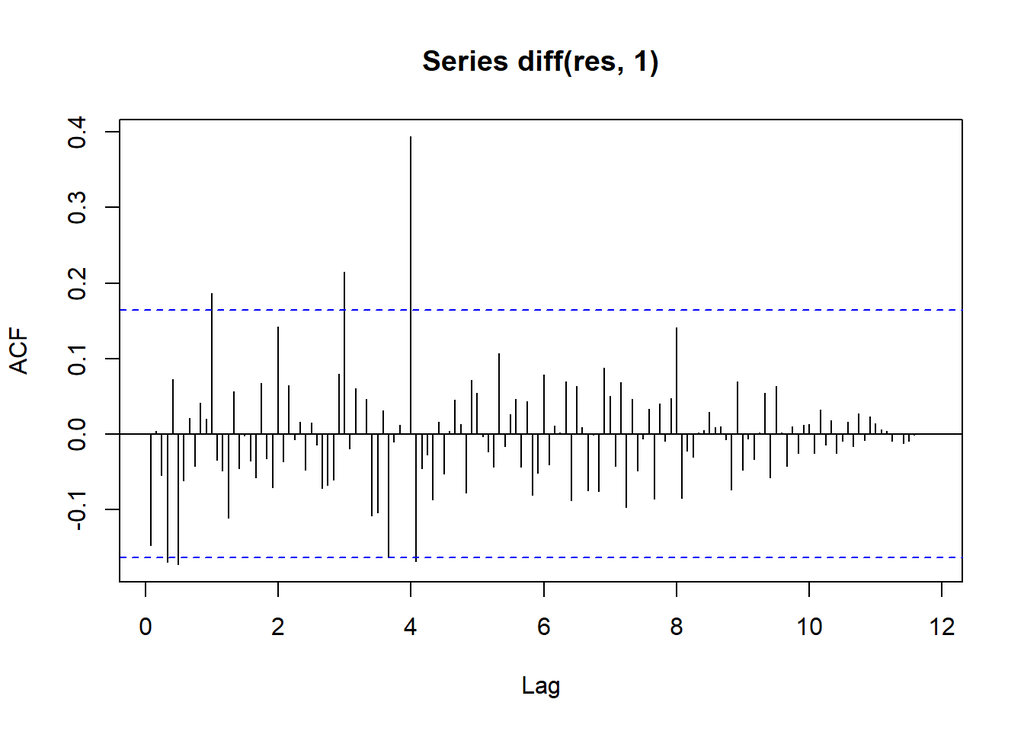

P-wartość jest powyżej poziomu istotności ($p-value = 0.07774$). Możemy również przeprowadzić metodę poznaną na wykładzie, aby utworzyć taki szereg ręcznie.

```r
a = itsmr::arma(res, p=1, q=0)
n = length(res)
a.ph<-a$phi
y <- rep(0,n)
y[1] = res[1]
for(i in 2:n)
  y[i] = res[i] -a.ph[1]*res[i-1]
```

Przeprowadzjąc analogiczny test, mamy:

```
##
##  Box-Pierce test
##
## data:  y
## X-squared = 0.010954, df = 1, p-value = 0.9166
```

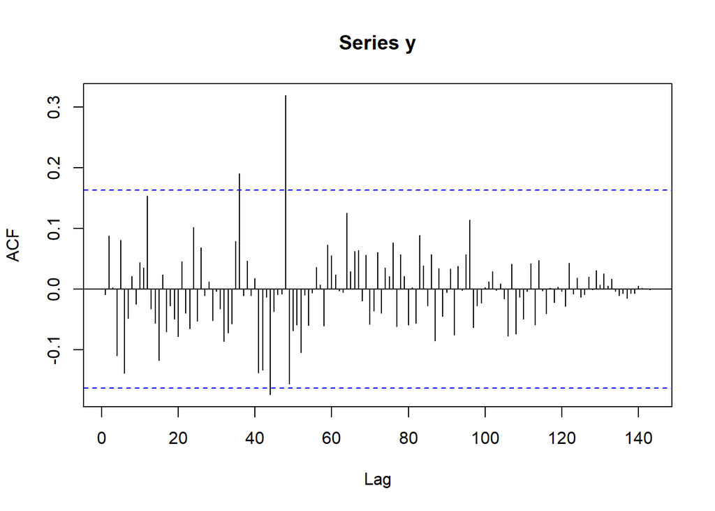

Porównajmy graficznie otrzymane szeregi.

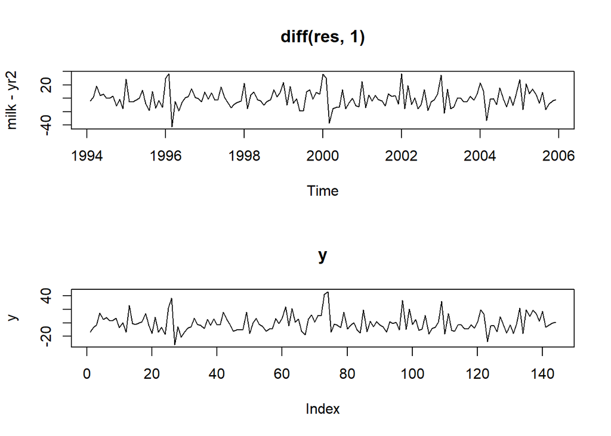

Istotnie, struktura (wzrosty i spadki) obu szeregów jest bardzo podobna. Dodatkowo, możemy dostrzec, że pojedyncza anomalia na przełomie milenium, chociaż nadal wystepuje, to nie ma większego wpływu na stacjonarność szeregu.

Zatem możemy przejść do predykcji, wykorzystując model $ARMA(1,0)$ dla “res”.